[figure not shown]

Отчет по лабораторной работе №6

Операционные системы

Никитенко Арина

Российский университет дружбы народов, Москва, Россия

1/39

[figure not shown]

Информация

[figure not shown]

Докладчик

Никитенко Арина Александровна

2/39

[figure not shown]

Докладчик

Никитенко Арина Александровна

НКАбд-07-25, Студенческий билет: 1132250435

2/39

[figure not shown]

Докладчик

Никитенко Арина Александровна

НКАбд-07-25, Студенческий билет: 1132250435

Российский университет дружбы народов

2/39

[figure not shown]

Цель работы

Приобрести практические навыки взаимодействия пользователя с

системой посредством командной строки.

3/39

[figure not shown]

Задание

4/39

[figure not shown]

Выполнение лабораторной работы

5/39

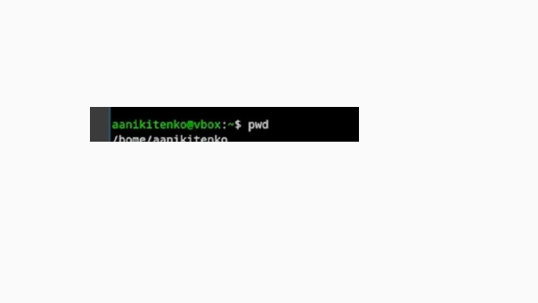

1.Определяем полное имя домашнего каталога.

Рисунок 1: pwd

6/39

2.Выполняем следующие действия.

7/39

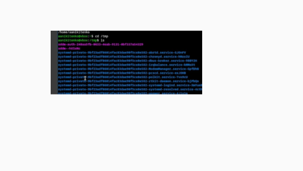

2.1 Переход в каталог tmp

Рисунок 2: cd /tmp

8/39

2.2 Вывод содержания каталога /tmp.Для этого используем команду ls с

разными опциями.

9/39

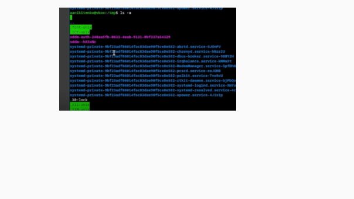

Рисунок 3: 2.2.1 ls -a(Показывает все файлы, включая те,которые скрытые)

10/39

[figure not shown]

Рисунок 4: 2.2.2 ls -F(Показывает имена + обозначения типов файлов)

11/39

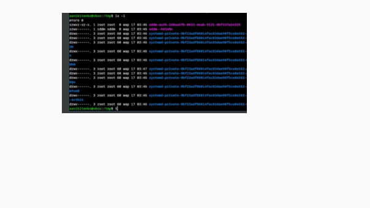

Рисунок 5: 2.2.3 ls -l(Показывает подробную информация о каждом файле)

12/39

[figure not shown]

13/39

Рисунок 6: 2.2.4 ls -laF(Показывает все файлы с подробной информацией и

символами типов.)

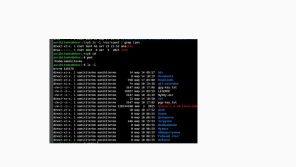

2.3-2.4 Определяем есть ли в каталоге /var/spool подкаталог с именем cron

и переходим в домашний каталог, выводим содержимае на экран и

определяем кто владелец

14/39

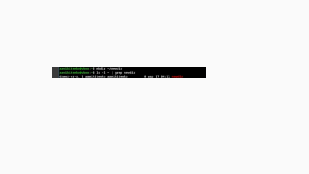

3.1 В домашнем каталоге создаём новый каталог newdir

Рисунок 8: 3.1 mkdir ~/newdir и проверка создался ли каталог

15/39

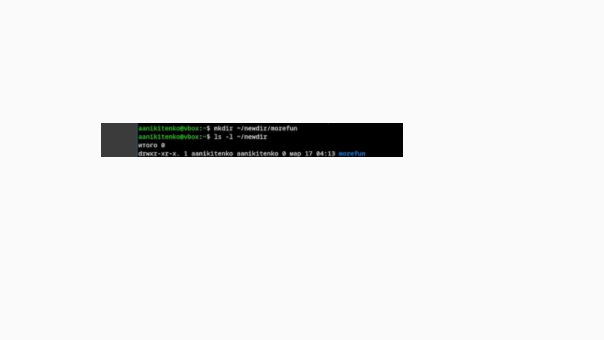

3.2 В каталоге ~/newdir создаём новый каталог morefun

Рисунок 9: 3.2. mkdir ~/nrwdir/morefun и проверяем

16/39

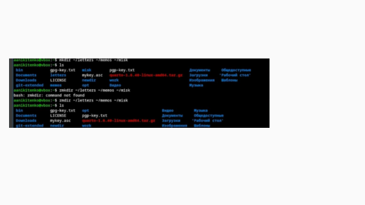

3.3 В домашнем каталоге создайте одной командой три новых каталога с

именами letters, memos, misk. Затем удаляем эти каталоги одной командой.

и проверяем удалился ли

17/39

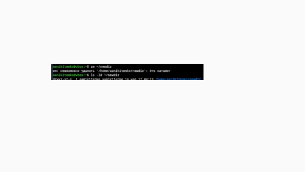

3.4 Попробуем удалить ранее созданный каталог ~/newdir командой rm.

Проверяем, был ли каталог удалён . Нет, каталог не удален

Рисунок 10: 3.4. rm ~/newdir(Каталог не удален, тк команда rm без опций не

удаляет каталоги.)

18/39

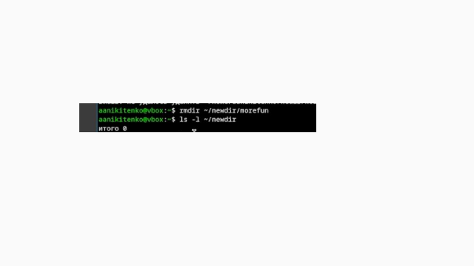

3.5 Удаляем каталог ~/newdir/morefun из домашнего каталога и проверяем

был ли удалён каталог.

Рисунок 11: 3.5. rmdir ~/newdir/morefun и проверяем, да, удалился

19/39

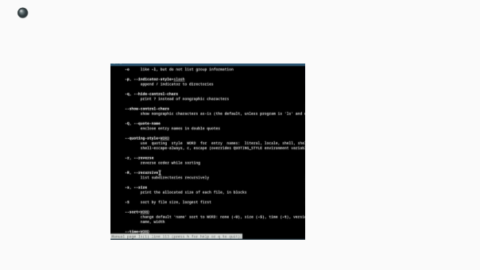

4

С помощью команды man определяем,какую опцию команды ls нужно

использовать для просмотра содержимого не только указанного

каталога, но и подкаталогов,входящего в него.

20/39

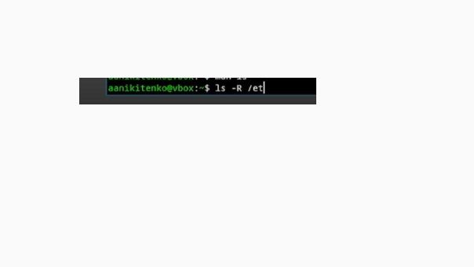

Рисунок 13: используем опцию -R, которая позволяет просмотреть содержимое

каталога и всех его каталогов

21/39

[figure not shown]

22/39

Рисунок 14: Пример,просмотра содержимого etc

5.С помощью команды man определяем набор опций команды ls,

позволяющий отсортировать по времени последнего изменения

выводимый список содержимого каталога с развёрнутым описанием

файлов.

23/39

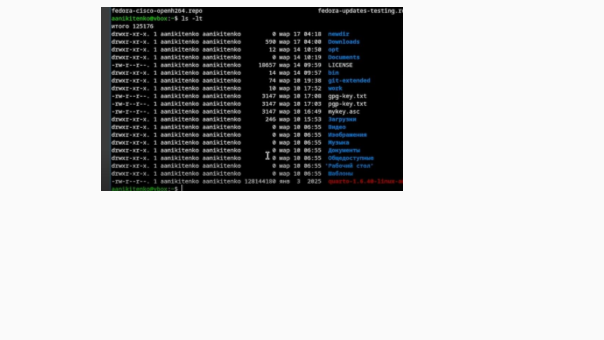

Рисунок 15: ls -lt -сортировка по времени с последнего изменения с развёрнутом

описанием

24/39

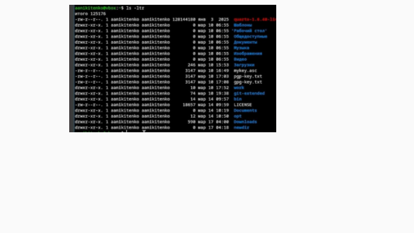

Рисунок 16: ls -ltr -сортировка по времени с последнего изменения с

развёрнутом описанием(старые будут выводится первыми )

25/39

6.Используем команду man для просмотра описания команд:

cd,pwd,mkdir,rmdir,rm. И поясняем.

26/39

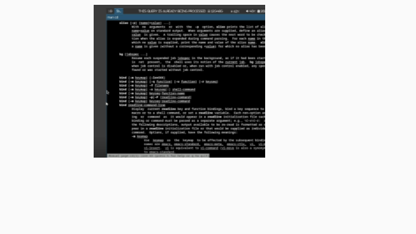

27/39

Рисунок 17: man cd

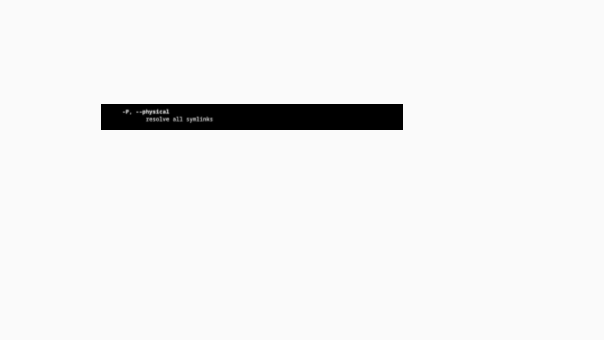

Рисунок 18: man pwd(-L показывает логический путь -Р показывает физический

путь)

28/39

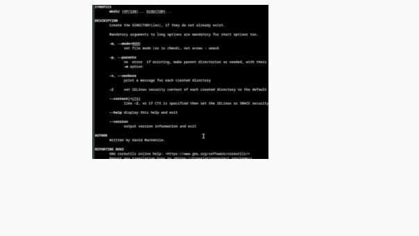